# main-notebook

```python
import pandas as pd
import numpy as np
import matplotlib.pyplot as plt
import time
import re
import seaborn as sns
sns.set()

from keplergl import KeplerGl

import datetime as dt

from IPython.display import display, HTML
display(HTML("<style>.container { width:100% !important; }</style>"))

import warnings
warnings.filterwarnings('ignore')
```

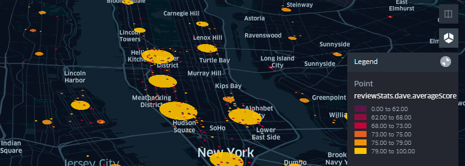

This project delves into the dataset to uncover trends, preferences, and insights behind Dave Portnoy's iconic pizza ratings.

With the help of some online tutorials, I was able to find the API being used by the barstool app. The general API is https://one-bite-api.barstoolsports.com and does not require any form of user authentication. The venue endpoint, accessed by adding /venue after the general API, contains the pizza scores and other useful information.

Example API Call:

https://one-bite-api.barstoolsports.com/venue?dave=0&lat=40.73&lon=-73.98&state=NY&zip=11216

Notes for API:

- returns a maximum of 100 items at a time
- has a `dave` boolean parameter, 1 for places Dave has been to, and 0 for places he has not
- has `zipcode` parameter, which gets converted into lat/long when retrieving data
- has `radius` parameter with units in millimeters

Implementing a grid search throughout the states would be inefficient since most of the Dave-reviewed pizza shops are located in high population cities near the east coast such as NYC, Boston, and so on. The barstool website has a list of all reviews including the locations. Each [page](https://onebite.app/reviews/dave?page=1&minScore=0&maxScore=10) has 30 reviews and there are a total of 54 pages. By inspecting the HTML elements that contain the city names, I found their respective names and indexes in the page source code.

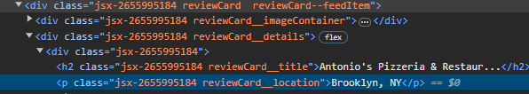

Then I used Selenium to go through each page and extract the city names.

```python
pageNumbers = range(1,55)
cityList = []

from selenium import webdriver
import urllib.request, json

for pageNumber in pageNumbers:
    base_url = 'https://onebite.app/reviews/dave?page=' + str(pageNumber) + '&minScore=0&maxScore=10'
    driver = webdriver.Chrome()
    driver.get(base_url)
    time.sleep(3)
    html_source = driver.page_source

    locations = [location.start() for location in re.finditer('reviewCard__location', html_source)]
    names = [name.start() for name in re.finditer('reviewCard__title', html_source)]
    index = 1
    for locationIndex in locations[2:]:
        locationElement = html_source[locationIndex:locationIndex+55]
        city = re.findall(r'">(.*)</p>', locationElement)[0]
        cityList.append(city)
```

```python
print("Dave has done " + str(len(cityList)) + " reviews in " + str(len(np.unique(cityList))) + " different cities.")
city
```

```
Dave has done 1619 reviews in 460 different cities.
```

```python
pd.DataFrame(data=pd.Series(cityList),columns={'cityName'}).to_csv('data/cities.csv', index=False)
```

```python
def splitCityName(cityState):
    '''
    Used to split "City, State" string to two different variables.
    '''
    index = cityState.find(',')
    city = cityState[:index]
    state = cityState[index+2:]
    return pd.Series([city,state])
```

```python
city_df = pd.DataFrame(data=pd.Series(cityList),columns={'cityName'}).reset_index().rename(columns={'index':'count'})
city_df[['city', 'state']] = city_df.apply(lambda x: splitCityName(x['cityName']), axis=1)
unique_city_df = city_df.drop_duplicates(['cityName'])
```

```python
review_counts = city_df.groupby('cityName').count().sort_values('count',ascending=False).reset_index().rename(columns={'count':'reviewCount'})
review_counts_top10 = review_counts.head(10)
```

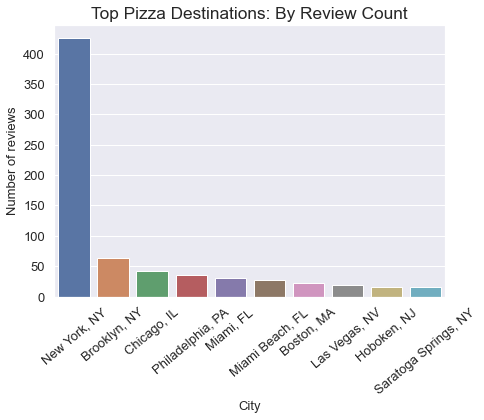

```python
plt.figure(figsize=(7,5))
sns.barplot(x=review_counts_top10['cityName'],y=review_counts_top10['reviewCount'])
plt.xticks(rotation=40, size=13);
plt.yticks(size=13)
plt.xlabel('City',size=13)
plt.ylabel('Number of reviews',size=13)
plt.title("Top Pizza Destinations: By Review Count", size='x-large');
```

Now that I have a list of cities Dave has visited, I know exactly where to search using the API.

```python
def getAPIurl(Lat,Lon):
    '''
    Returns API url using lat/long search
    '''
    lat = round(Lat,2)
    lon = round(Lon,2)
    return("https://one-bite-api.barstoolsports.com/venue?dave=1&lat=" + str(Lat) + "&lon=" + str(Lon))
```

```python
us_city_df = pd.read_csv('data/uscities.csv') # Dataset from https://simplemaps.com/data/us-cities
print(us_city_df.columns)
us_city_df['cityName'] = us_city_df['city'] + ', ' + us_city_df['state_id']
us_city_df = us_city_df[['cityName', 'state_name', 'lat', 'lng', 'zips']]
```

```
Index(['city', 'city_ascii', 'state_id', 'state_name', 'county_fips',
       'county_name', 'lat', 'lng', 'population', 'density', 'source',
       'military', 'incorporated', 'timezone', 'ranking', 'zips', 'id'],
      dtype='object')
```

```python
us_city_df = pd.merge(left=unique_city_df, right=us_city_df,on='cityName')
us_city_df.head(5)
```

|  | count | cityName | city | state | state_name | lat | lng | zips |
| --- | --- | --- | --- | --- | --- | --- | --- | --- |
| 0 | 0 | Brooklyn, NY | Brooklyn | NY | New York | 40.6501 | -73.9496 | 11229 11226 11225 11224 11223 11221 11220 1124... |
| 1 | 1 | Fort Worth, TX | Fort Worth | TX | Texas | 32.7817 | -97.3474 | 76164 76040 76134 76135 76137 76131 76132 7613... |
| 2 | 2 | Hazel Park, MI | Hazel Park | MI | Michigan | 42.4619 | -83.0977 | 48030 |
| 3 | 3 | Royal Oak, MI | Royal Oak | MI | Michigan | 42.5084 | -83.1539 | 48067 48073 48068 |
| 4 | 4 | Detroit, MI | Detroit | MI | Michigan | 42.3834 | -83.1024 | 48209 48208 48202 48201 48207 48206 48205 4820... |

The dataset from simplemaps contains the lat,long coordinates of every city and the corresponding zipcodes. We can use the zipcodes to generate more lat/long coordinates for cities like NYC where the review count is larger than the API limit.

```python
df_reviews = pd.DataFrame()
for index, row in us_city_df.iterrows():
    with urllib.request.urlopen(getAPIurl(Lat=row['lat'],Lon=row['lng'])) as url:
        data = json.loads(url.read().decode())
        df = pd.json_normalize(data)
        df_reviews = pd.concat([df_reviews, df], ignore_index=True)
        df_reviews = df_reviews.drop_duplicates(subset=['address1', 'createdAt'])
```

```python
print("Retrieved " + str(len(df_reviews)) + " reviews.")
df_reviews.columns
#df_reviews.to_csv('data/pizza-data.csv',index=False)
```

```
Retrieved 1471 reviews.
```

```
Index(['deleted', 'orderProvider', 'placeId', 'address1', 'address2',
       'categories', 'city', 'country', 'createdAt', 'imageUrl', 'modifiedAt',
       'name', 'phoneNumber', 'priceLevel', 'providerRating',
       'providerReviewCount', 'providerTransactions', 'providerUrl', 'state',
       'type', 'zip', 'openHours', 'photos', 'refreshDate', 'timeZone',
       '_distance', 'id', 'slug', 'reviewStats.all.count',
       'reviewStats.all.totalScore', 'reviewStats.all.averageScore',
       'reviewStats.community.count', 'reviewStats.community.totalScore',
       'reviewStats.community.averageScore', 'reviewStats.critic.count',
       'reviewStats.critic.totalScore', 'reviewStats.critic.averageScore',
       'reviewStats.dave.count', 'reviewStats.dave.totalScore',
       'reviewStats.dave.averageScore', 'loc.type', 'loc.coordinates',
       'featuredMedia.streams.mp4', 'featuredMedia.streams.hls',
       'featuredMedia.thumbnails.small', 'featuredMedia.thumbnails.medium',
       'featuredMedia.thumbnails.large', 'featuredMedia.metadata.aspectRatio',
       'featuredMedia.metadata.duration', 'featuredMedia.metadata.frameRate',
       'featuredMedia.metadata.resolution', 'featuredMedia._id',
       'featuredMedia.deleted', 'featuredMedia.user', 'featuredMedia.status',
       'featuredMedia.type', 'featuredMedia.sourceUrl',
       'featuredMedia.assetId', 'featuredMedia.playbackId',
       'featuredMedia.reviewId', 'featuredMedia.createdAt',
       'featuredMedia.modifiedAt', 'featuredMedia.__v', 'featuredMedia.id',
       'featuredMedia.__t', 'orderProvider.name', 'orderProvider.checkoutUrl',
       'orderProvider.internalId', 'orderProvider.logo', 'orderProvider._id'],
      dtype='object')
```

The API returns a lot of information including name and location of venues, open hours, review video duration, and Dave and the community's review scores.

```python
df_reviews.isna().sum().to_string()
```

[output not shown]

Dave uses a simple 0 to 10 scoring system. Here's a more detailed breakdown:

- Anything below 3.0 is virtually inedible
- 3.1 to 5.0: is below "average"
- 5.1 to 7.0: is considered football pizza, good for large gatherings or if you are drunk, but nothing too special
- 7.1 to 8.0: pizzas in this range are considered good to very good, and they can be your regular local pizza spot
- 8.1 to 9.0: pizzas in this range are considered excellent, and are worth travelling at least a few hours to try them
- 9.1 to 10.0: pizzas in this range are considered outstanding and nearly perfect.

```python
#pizza_df = pd.read_csv('data/pizza-data.csv')
```

```python
print(f"The median review score for all data is {pizza_df['reviewStats.dave.averageScore'].median():.1f} with a standard deviation of {pizza_df['reviewStats.dave.averageScore'].std():.1f}.")
```

```
The median review score for all data is 7.3 with a standard deviation of 1.4.
```

## Top 10 Pizza shops by score

```python
high_scores = df_reviews.sort_values(by='reviewStats.dave.averageScore', ascending=False).reset_index(drop=True)
high_scores[['name', 'city', 'state','reviewStats.dave.averageScore']].head(10)
```

|  | name | city | state | reviewStats.dave.averageScore |
| --- | --- | --- | --- | --- |
| 0 | Monte's Restaurant | Lynn | MA | 10.0 |
| 1 | Di Fara Pizza | Brooklyn | NY | 9.4 |
| 2 | DeLucia's Brick Oven Pizza | Raritan | NJ | 9.4 |
| 3 | Frank Pepe Pizzeria Napoletana | Chestnut Hill | MA | 9.4 |
| 4 | Oath Pizza - Nantucket | Nantucket | MA | 9.3 |
| 5 | Lucali | Brooklyn | NY | 9.3 |
| 6 | John's of Bleecker Street | New York | NY | 9.3 |
| 7 | Lazzara's Pizza | New York | NY | 9.3 |
| 8 | Luigi's Pizza | Brooklyn | NY | 9.3 |
| 9 | Angelo's Coal Oven Pizzeria | New York | NY | 9.3 |

```python
cities_df = pizza_df.groupby('city')['reviewStats.dave.averageScore'].agg(avg='mean', size='size')
cities_df = cities_df.sort_values(by='avg', ascending=False)
top6_cities = cities_df[cities_df['size'] >= 10].sort_values(by='size', ascending=False).head(6).reset_index().rename(columns={'avg':'dave_score'})
top6_cities.head(6)
```

|  | city | dave_score | size |
| --- | --- | --- | --- |
| 0 | New York | 6.362575 | 299 |
| 1 | Brooklyn | 7.660317 | 63 |
| 2 | Chicago | 7.276190 | 42 |
| 3 | Philadelphia | 7.083333 | 36 |
| 4 | Miami | 7.216667 | 30 |
| 5 | Miami Beach | 6.762963 | 27 |

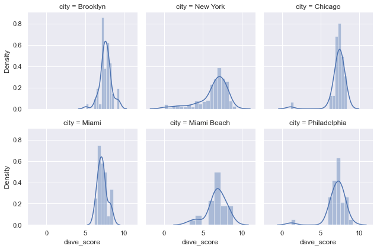

```python
filtered_pizza = pizza_df[pizza_df['city'].isin(top6_cities['city'])]
filtered_pizza['dave_score'] = filtered_pizza['reviewStats.dave.averageScore']

g = sns.FacetGrid(filtered_pizza, col="city", col_wrap=3)
g = g.map(sns.distplot, "dave_score")
```

The distributions of the top reviewed cities follow similar patterns; left-skewed and centered near 7.

## Pizza capital of the world

```python
cities_df = pizza_df.groupby('city')['reviewStats.dave.averageScore'].agg(avg='mean', size='size')
cities_df = cities_df.sort_values(by='avg', ascending=False)
pizza_capital_df = cities_df[cities_df['size'] >= 5].sort_values(by='avg', ascending=False).head(100).reset_index().rename(columns={'avg':'avg_dave_score'})
pizza_capital_df.head(5)
```

|  | city | avg_dave_score | size |
| --- | --- | --- | --- |
| 0 | New Haven | 7.833333 | 9 |
| 1 | Staten Island | 7.720000 | 10 |
| 2 | Brooklyn | 7.660317 | 63 |
| 3 | Jersey City | 7.550000 | 8 |
| 4 | Toronto | 7.528571 | 14 |

It should be no surprise that New Haven is at the top of the list. New Haven pizza, or "apizza", is renowned for its thin, coal-fired crust, and high quality ingredients.

## Dave's ratings over time

```python
pizza_df['createdAt'] = pd.to_datetime(pizza_df['createdAt'])
pizza_df['featuredMedia.createdAt'] = pd.to_datetime(pizza_df['featuredMedia.createdAt'])
timeseries_df = pizza_df[['featuredMedia.createdAt','city','name','reviewStats.dave.averageScore']].rename(columns={'reviewStats.dave.averageScore':'dave_score',
                                                                                                     'featuredMedia.createdAt':'date'}).sort_values(by=['date']).reset_index(drop=True)
timeseries_df['dave_score_cumsum'] = timeseries_df['dave_score'].cumsum()
timeseries_df = timeseries_df.reset_index()
timeseries_df['index'] = timeseries_df['index'] + 1
timeseries_df['dave_score_rolling_average'] = np.round(timeseries_df['dave_score_cumsum'] / timeseries_df['index'],2)
timeseries_df.head(5)
```

|  | index | date | city | name | dave_score | dave_score_cumsum | dave_score_rolling_average |
| --- | --- | --- | --- | --- | --- | --- | --- |
| 0 | 1 | 2018-03-23 17:38:24.269000+00:00 | Bronx | Pugsley's Pizza | 7.7 | 7.7 | 7.70 |
| 1 | 2 | 2018-03-23 17:38:26.645000+00:00 | Brooklyn | Williamsburg Pizza | 8.6 | 16.3 | 8.15 |
| 2 | 3 | 2018-03-23 17:38:31.358000+00:00 | New York | Nino's 46 | 6.9 | 23.2 | 7.73 |
| 3 | 4 | 2018-03-23 17:38:38.259000+00:00 | New York | La Gusto Pizza | 3.2 | 26.4 | 6.60 |
| 4 | 5 | 2018-03-23 17:38:40.383000+00:00 | New York | Cheesy Pizza | 6.1 | 32.5 | 6.50 |

```python
median_list = []
for index in range(3,len(timeseries_df)):
    scores = timeseries_df.iloc[:index]['dave_score']
    median_score = scores.median()
    median_list.append(median_score)
```

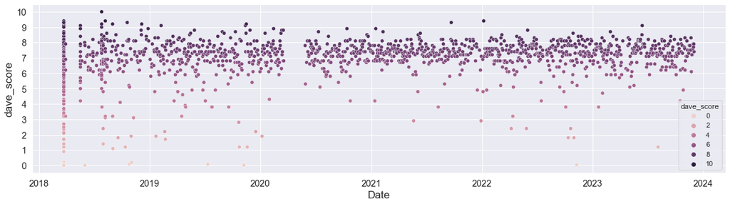

```python
plt.figure(figsize=(20,5))
sns.scatterplot(data=timeseries_df, x="date", y="dave_score", hue="dave_score")
#sns.lineplot(data=timeseries_df, x="date", y="dave_score_rolling_average")
plt.yticks(ticks=np.arange(0,11));
plt.xticks(size='large')
plt.yticks(size='large')
plt.xlabel('Date', size='x-large')
plt.ylabel('dave_score', size='x-large');
```

Overall, Dave seems pretty consistent in his ratings. He has stated in multiple reviews he was particularly generous early on (first 10 to 20 reviews), and there were definitely some ratings higher than deserved. Obviously, the pizza reviews stopped when quarantines measures started and resumed when they were over. By observation, there seem to be less low scores (<5) after the quarantine than before.

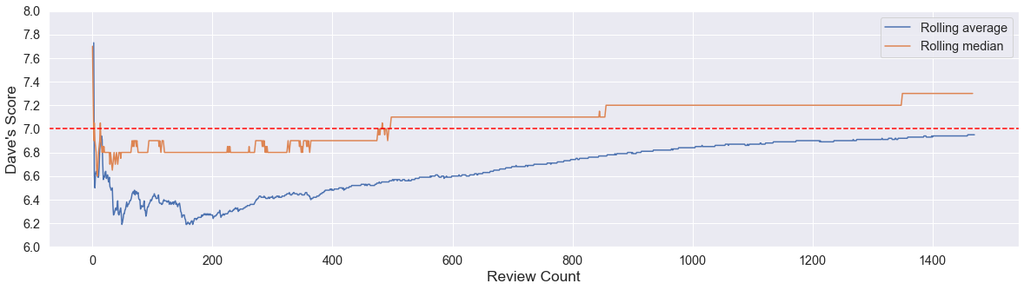

```python
plt.figure(figsize=(20,5))
plt.ylim([6,8])
plt.plot(timeseries_df['dave_score_rolling_average'].iloc[2:], label='Rolling average')
plt.plot(median_list, label='Rolling median')
plt.axhline(y=7, color='red', linestyle='--')
plt.xticks(size='large')
plt.yticks(np.linspace(6,8,11), size='large')
plt.xlabel("Review Count", size='x-large')
plt.ylabel("Dave's Score", size='x-large')
plt.legend(fontsize='large');
```

As the sample size gets larger, Dave's average score approaches 7, represented by the red dashed line.

Let's take a closer look at Dave's scores before and after the pandemic.

```python
timeseries_df_before = timeseries_df[timeseries_df['date'] < '2020-03-15']
timeseries_df_after = timeseries_df[timeseries_df['date'] >= '2020-03-15']
```

[figure not shown]

```python
fig, ax = plt.subplots(figsize=(10,5))

import matplotlib.patches as mpatches
import matplotlib.pyplot as plt

orange_patch = mpatches.Patch(color='orange', label='Before COVID')
blue_patch = mpatches.Patch(color='lightskyblue', label='After COVID')
plt.xlim([0,10])
plt.xticks(ticks=np.arange(0,11));
plt.yticks(ticks=np.linspace(0,1,11));

sns.distplot(timeseries_df_before['dave_score'], ax=ax)
sns.distplot(timeseries_df_after['dave_score'], ax=ax)
handles, labels = ax.get_legend_handles_labels()
ax.legend(handles, labels)
plt.legend(handles=[orange_patch, blue_patch])
plt.xlabel("Pizza Review Scores")
plt.ylabel("Propensity");
```

```python
print(f"The mean review score before COVID-19 is {timeseries_df_before['dave_score'].mean():.1f} with a standard deviation of {timeseries_df_before['dave_score'].std():.1f}.")
print(f"The mean review score after COVID-19 is {timeseries_df_after['dave_score'].mean():.1f} with a standard deviation of {timeseries_df_after['dave_score'].std():.1f}.")
```

```
The mean review score before COVID-19 is 6.8 with a standard deviation of 1.6.
The mean review score after COVID-19 is 7.2 with a standard deviation of 1.0.
```

The average score for reviews after the quarantine is 0.4 points higher than before the quarantine.

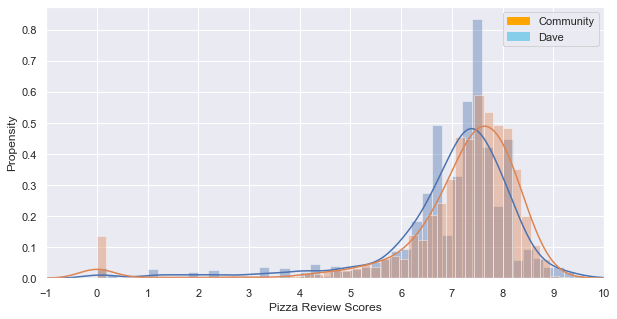

```python
fig, ax = plt.subplots(figsize=(10,5))

orange_patch = mpatches.Patch(color='orange', label='Community')
blue_patch = mpatches.Patch(color='skyblue', label='Dave')
plt.xlim([0,10])
plt.xticks(ticks=np.arange(-1,11));
plt.yticks(ticks=np.linspace(0,1,11));

types = ['reviewStats.dave.averageScore', 'reviewStats.community.averageScore']
for col in types:
    sns.distplot(pizza_df[col], ax=ax)
handles, labels = ax.get_legend_handles_labels()
ax.legend(handles, labels)
plt.legend(handles=[orange_patch, blue_patch])
plt.xlabel("Pizza Review Scores")
plt.ylabel("Propensity")
```

```python
import scipy.stats as st
def get_test_results(data):
    test_names = ["levene", "mannwhitneyu", "median_test"]
    test_results = []
    params = {}
    for test_name in test_names:
        test = getattr(st, test_name)
        param = test(data[0], data[1])

        params[test_name] = param
        # Applying the Kolmogorov-Smirnov test
        p = param[1]
        print("p value for "+test_name+" = "+str(p))
        test_results.append((test_name, p))
```

```python
get_test_results([pizza_df['reviewStats.dave.averageScore'], pizza_df['reviewStats.community.averageScore']])
```

```
p value for levene = 0.5954199535225673
p value for mannwhitneyu = 7.907770731027693e-12
p value for median_test = 2.4403532524143715e-07
```

```python
def get_best_distribution(data):
    dist_names = ["norm", "exponweib", "weibull_max", "weibull_min", "pareto", "genextreme"]
    dist_results = []
    params = {}
    for dist_name in dist_names:
        dist = getattr(st, dist_name)
        param = dist.fit(data)

        params[dist_name] = param
        # Applying the Kolmogorov-Smirnov test
        D, p = st.kstest(data, dist_name, args=param)
        print("p value for "+dist_name+" = "+str(p))
        dist_results.append((dist_name, p))

    # select the best fitted distribution
    best_dist, best_p = (max(dist_results, key=lambda item: item[1]))
    # store the name of the best fit and its p value

    print("Best fitting distribution: "+str(best_dist))
    print("Best p value: "+ str(best_p))
    print("Parameters for the best fit: "+ str(params[best_dist]))

    return best_dist, best_p, params[best_dist]
```

```python
pizza_distribution = get_best_distribution(pizza_df['reviewStats.dave.averageScore'])
```

```
p value for norm = 3.6546532599914025e-46
p value for exponweib = 2.3414984902663178e-12
p value for weibull_max = 9.689364027210613e-34
p value for weibull_min = 0.0
p value for pareto = 5.618710950443341e-299
p value for genextreme = 9.721364747406004e-34
Best fitting distribution: exponweib
Best p value: 2.3414984902663178e-12
Parameters for the best fit: (0.6985506680844615, 70210.43454016485, -52487.553236639156, 52495.325509934744)
```

# Geomapping

The coordinates from barstool database are not accurate. We will need to use a geocode API to get precise coordinates.

```python
pizza_df['address_total'] = pizza_df['address1'] + ", " + pizza_df['city'] + ", " + pizza_df['country']
pizza_df.iloc[0]['address_total']
```

```
'905 Church Ave, Brooklyn, US'
```

```python
import requests

api_key = ""
def get_google_results(address, api_key=None, return_full_response=False):
    # Set up your Geocoding url
    geocode_url = "https://maps.googleapis.com/maps/api/geocode/json?address={}".format(address)
    if api_key is not None:
        geocode_url = geocode_url + "&key={}".format(api_key)

    # Ping google for the reuslts:
    results = requests.get(geocode_url)
    # Results will be in JSON format - convert to dict using requests functionality
    results = results.json()

    # if there's no results or an error, return empty results.
    if len(results['results']) == 0:
        output = {
            "formatted_address" : None,
            "latitude": None,
            "longitude": None,
            "accuracy": None,
            "google_place_id": None,
            "type": None,
            "postcode": None
        }
    else:
        answer = results['results'][0]
        output = {
            "formatted_address" : answer.get('formatted_address'),
            "latitude": answer.get('geometry').get('location').get('lat'),
            "longitude": answer.get('geometry').get('location').get('lng'),
            "accuracy": answer.get('geometry').get('location_type'),
            "google_place_id": answer.get("place_id"),
            "type": ",".join(answer.get('types')),
            "postcode": ",".join([x['long_name'] for x in answer.get('address_components')
                                  if 'postal_code' in x.get('types')])
        }

    # Append some other details:
    output['input_string'] = address
    output['number_of_results'] = len(results['results'])
    output['status'] = results.get('status')
    if return_full_response is True:
        output['response'] = results

    return output
```

```python
results = []
for address in pizza_df['address_total']:
    geocoded = False
    while geocoded is not True:
        try:
            geocode_result = get_google_results(address, api_key, return_full_response=True)
        except Exception as e:
            print(e)
            print("Major error with {}".format(address))
            print("Skipping!")
            geocoded = True

        if geocode_result['status'] == 'OVER_QUERY_LIMIT':
            print("Hit Query Limit! Backing off for a bit.")
            time.sleep(BACKOFF_TIME * 60) # sleep for 30 minutes
            geocoded = False
        else:
            if geocode_result['status'] != 'OK':
                print("Error geocoding {}: {}".format(address, geocode_result['status']))
            print("Geocoded: {}: {}".format(address, geocode_result['status']))
            results.append(geocode_result)
            geocoded = True
```

```python
pizza_df = pd.concat([pizza_df, pd.json_normalize(results)], axis=1)
#pizza_df.to_csv("data/pizza_data2.csv", index=False)
```

```python
pizza_df = pizza_df.rename(columns={'latitude':'Latitude', 'longitude':'Longitude'})
```

```python
geomap_df = pizza_df[['name', 'Latitude', 'Longitude', 'reviewStats.dave.averageScore']]
geomap_df['reviewStats.dave.averageScore'] = geomap_df['reviewStats.dave.averageScore'] * 10
```

```python
map_1 = KeplerGl(height=400, data={"data_1": geomap_df})
map_1
```

```
User Guide: https://docs.kepler.gl/docs/keplergl-jupyter
```

[output not shown]

## Final notes:

Wrangling this data was like solving a puzzle, and analyzing it felt like uncovering hidden secrets. From messy CSVs to insightful visualizations, we've come a long way.